# *Census at School* Survey Analysis

Annonymous for Now

February 9, 2019

I selected 100 total samples from all states from students in grades 6-12 from *Census at School*: https://ww2.amstat.org/censusatschool/Exports/1549761705425_DATA.csv

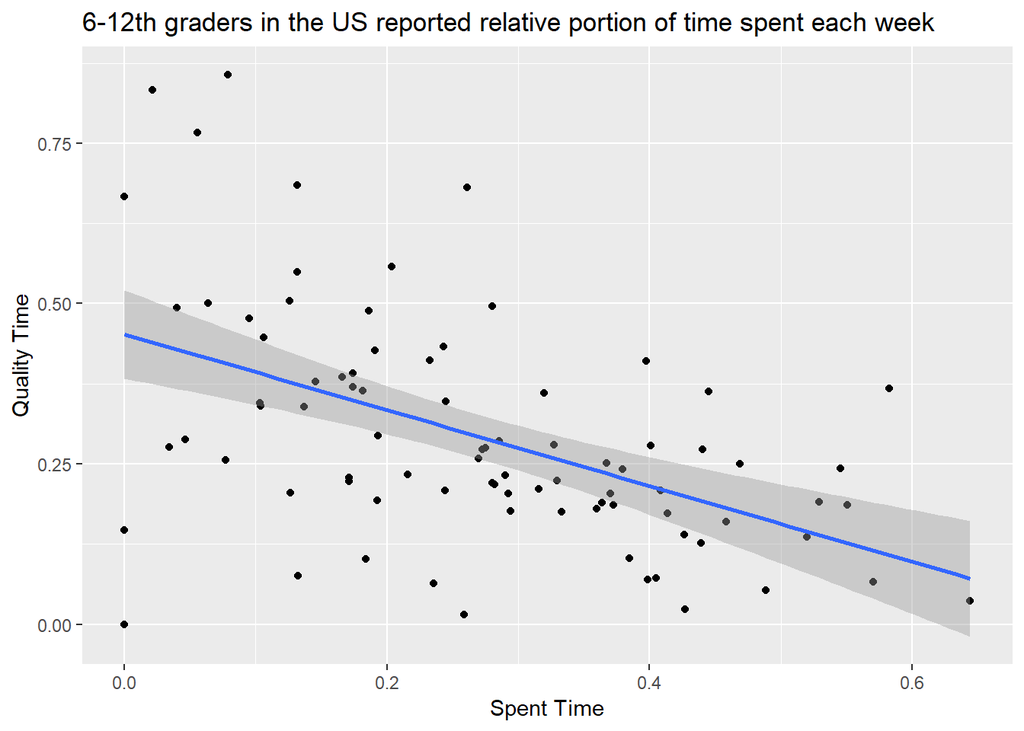

```r
setwd("C:/Users/Jim/Desktop/MATH 325/Math 325 Notebook/Math_425_Project_Data")

data <- read_csv("data/1549761705425_DATA.csv") %>%
  mutate(Outdoor_Activities_Hours = as.numeric(Outdoor_Activities_Hours)) %>%
  replace_na(list(Hanging_Out_With_Friends_Hours = 0, Talking_On_Phone_Hours = 0, Doing_Homework_Hours = 0, Doing_Things_With_Family_Hours = 0, Outdoor_Activities_Hours = 0, Video_Games_Hours = 0, Social_Websites_Hours = 0, Texting_Messaging_Hours = 0, Computer_Use_Hours = 0, Watching_TV_Hours = 0, Paid_Work_Hours = 0, Work_At_Home_Hours = 0)) %>%
  mutate(TotalHours = Hanging_Out_With_Friends_Hours + Talking_On_Phone_Hours + Doing_Homework_Hours + Doing_Things_With_Family_Hours + Outdoor_Activities_Hours + Video_Games_Hours + Social_Websites_Hours + Texting_Messaging_Hours + Computer_Use_Hours + Watching_TV_Hours + Paid_Work_Hours + Work_At_Home_Hours) %>%
  mutate(QualityTime = (Doing_Things_With_Family_Hours + Outdoor_Activities_Hours + Paid_Work_Hours + Work_At_Home_Hours) / TotalHours, SpentTime = (Social_Websites_Hours + Texting_Messaging_Hours + Video_Games_Hours + Watching_TV_Hours) / TotalHours) %>%
  select(TotalHours, QualityTime, SpentTime) %>%
  filter(TotalHours != 0)

time_lm <- lm(QualityTime ~ SpentTime, dat = data)

ggplot(data, aes(x = SpentTime, y = QualityTime)) +
  geom_point() +
  geom_smooth(method = lm) +
  labs(title = "6-12th graders in the US reported relative portion of time spent each week", x = "Spent Time", y = "Quality Time")
```

(‘Doing_Things_With_Family_Hours’, ‘Outdoor_Activities_Hours’, ‘Paid_Work_Hours’, and ‘Work_At_Home_Hours’.)

(‘Social_Websites_Hours’, ‘Texting_Messaging_Hours’, ‘Video_Games_Hours’, and ‘Watching_TV_Hours’).

Because students wildly varied on their estimations of how many hours are in a given week, I divided their reported hours by the total to get a percentage of all hours. The total time was aggregated from all of these activities, which do not include everything that happens in a day, like sleeping:

‘Hanging_Out_With_Friends_Hours’, ‘Talking_On_Phone_Hours’, ‘Doing_Homework_Hours’, ‘Doing_Things_With_Family_Hours’,

‘Outdoor_Activities_Hours’, ‘Video_Games_Hours’, ‘Social_Websites_Hours’, ‘Texting_Messaging_Hours’,

‘Computer_Use_Hours’, ‘Watching_TV_Hours’, ‘Paid_Work_Hours’, ‘Work_At_Home_Hours’

It is important to note that I replaced all missing values with zeros. This is logical in some cases (e.g. A student doesn’t include a number if it was zero), but clearly misrepresentative for others (e.g. A student started filling out numbers but stopped midway). After aggregating, the model does not include any rows where the total hours reported is zero; there is only one instance where the total hours were 12, but the ‘SpentTime’ and ‘QualityTime’ hours were both reported as 0 and that one has been kept. After dropping rows there are 85 remaining, and a resulting 83 degrees of freedom for the linear regression.

I used the following hypothesis statements for a simple linear regression:
$$H_0: \beta_0 = 0 \\
H_0: \beta_1 = 0 \\
H_a: \beta_0 \ne 0 \\
H_a: \beta_1 \ne 0 \\
\alpha = 0.05$$
It would be surprising if either null hypothesis was not rejected. These are the results of the analysis:

```r
pander(summary(time_lm))
```

|  | Estimate | Std. Error | t value | Pr(>\|t\|) |
| --- | --- | --- | --- | --- |
| **(Intercept)** | 0.4523 | 0.0347 | 13.03 | 8.822e-22 |
| **SpentTime** | -0.5912 | 0.1118 | -5.286 | 9.924e-07 |

Fitting linear model: QualityTime ~ SpentTime

| Observations | Residual Std. Error | $R^2$ | Adjusted $R^2$ |
| --- | --- | --- | --- |
| 85 | 0.1589 | 0.2519 | 0.2428 |

$$\underbrace{\hat{Y}_i}_\text{Quality Time} = 0.4523 - 0.5912 \times \underbrace{X_i}_\text{Spent Time}$$

Both null hypotheses should be rejected. The intercept value is meaningful in this case, because I can observe that students who spend no time in the less valuable activities listed spend an average of 45% of the time used on the more valuable acivities listed.

The 95% confidence interval for the intercept is from 0.383 to 0.521 and the interval for the slope is from -0.814 to -0.369. The confidence band is shown in the graph and represents 95% of the other models that could have been obtained with a different sample. Nicholas Taleb may now comment.

These are the diagnostic plots. An ordered values plot should not be necessary because the way the data was sampled.

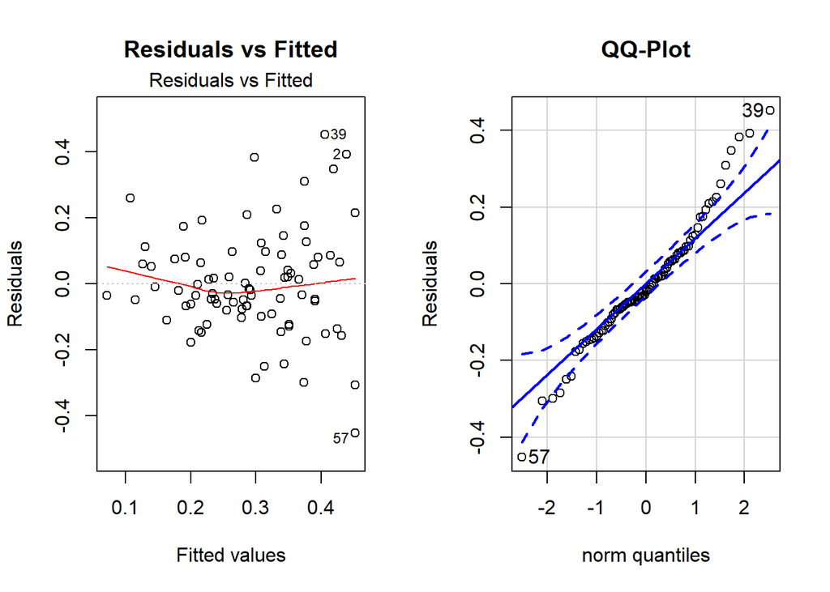

```
## [1] 57 39
```

```r
par(mfrow = c(1,2))
plot(time_lm, which = 1, main = "Residuals vs Fitted")
qqPlot(time_lm$residuals, main = "QQ-Plot", ylab = "Residuals")
```